# Tutorial K-Means

Tim Fundamental Sains Data

11/17/2020

Tutorial ini adalah bagian dari mata kuliah Fundamental Sains Data, Informatika, UII, disusun sebagian berdasarkan contoh yang ada [di sini](https://www.r-bloggers.com/2010/09/bot-botany-k-means-and-ggplot2/).

### Contoh A

Pada contoh ini, kita akan menggunakan data iris yang ada di package datasets. Untuk itu, jika belum meng-install package tersebut, silakan install terlebih dahulu.

```r
library("datasets")
data("iris")
summary(iris)
```

```
##   Sepal.Length    Sepal.Width     Petal.Length    Petal.Width
##  Min.   :4.300   Min.   :2.000   Min.   :1.000   Min.   :0.100
##  1st Qu.:5.100   1st Qu.:2.800   1st Qu.:1.600   1st Qu.:0.300
##  Median :5.800   Median :3.000   Median :4.350   Median :1.300
##  Mean   :5.843   Mean   :3.057   Mean   :3.758   Mean   :1.199
##  3rd Qu.:6.400   3rd Qu.:3.300   3rd Qu.:5.100   3rd Qu.:1.800
##  Max.   :7.900   Max.   :4.400   Max.   :6.900   Max.   :2.500
##        Species
##  setosa    :50
##  versicolor:50
##  virginica :50
##
##
##
```

Pada contoh ini, kita akan melakukan clustering menggunakan K-Means pada data set bunga iris, berdasarkan empat variabel pertama, yaitu `Sepal.Length`, `Sepal.Width`, `Petal.length`, dan `Petal.Width`. Di sini, kita tidak akan menggunakan variabel kelas Species dan mencari cluster.

```r
iris.new <- iris[, 1:4]
iris.class <- iris[, "Species"]
set.seed(1356)
result <- kmeans(iris.new, 3)
```

Secara spesifik, contoh di atas mencari 3 cluster dari data set `iris` (lihat baris ke-4). Selanjutnya, kita akan membuat beberapa plot untuk memvisualisasikan hasil clustering menggunakan K-Means.

Perhatikan script di bawah ini, baris ke-1, parameter `mfrow=c(2,2)` membagi ruang plot menjadi 2 baris dan 2 kolom, yang artinya ada 4 plot yang mungkin untuk ditampilkan bersama. Adapun parameter `mar=c(5,4,2,2)` mengatur ukuran margin dari plot.

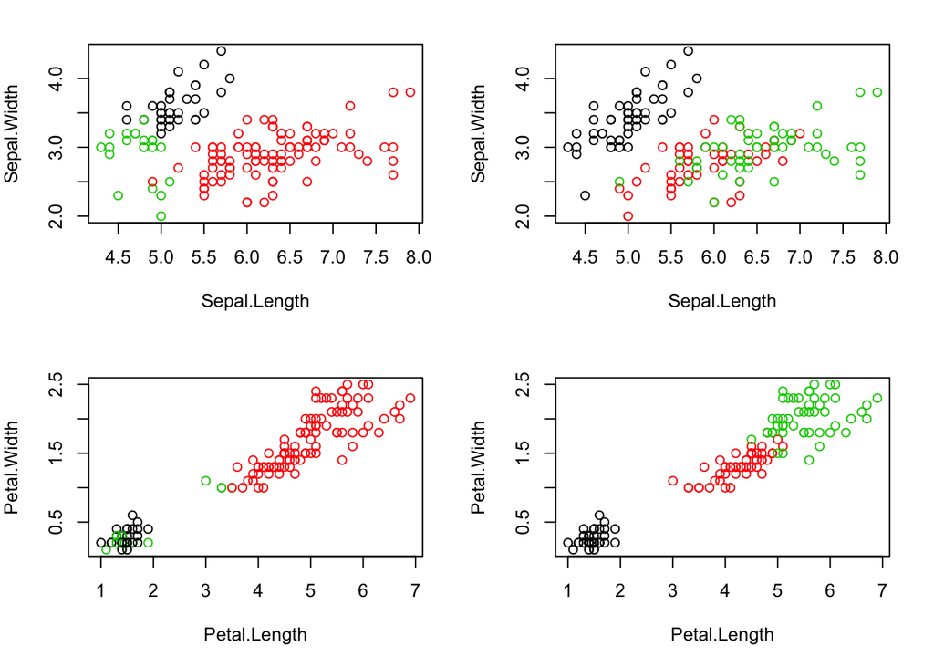

```r
par(mfrow=c(2,2), mar=c(5,4,2,2))
plot(iris.new[, c(1,2)], col=result$cluster)
plot(iris.new[, c(1,2)], col=iris.class)
plot(iris.new[, c(3,4)], col=result$cluster)
plot(iris.new[, c(3,4)], col=iris.class)
```

Plot pada kolom di sebelah kiri adalah hasil clustering menggunakan K-Means, sedangkan plot pada kolom sebelah kanan adalah plot spesies bunga iris berdasarkan dua variabel; `Sepal.Width-Sepal.Length` (plot di kanan-atas), `Petal.Width-Petal.Length` (plot di kanan bawah).

Di materi yang kita bahas di kelas, kita mengevaluasi **cost** function yang disebut sebagai **distortion** function. Di sini nilai distortion pada iterasi terakhir dapat dilihat melalui `tot.withinss`.

```r
result$tot.withinss
```

```
## [1] 142.7535
```